# Aides Drug

Erika Munoz

11/16/2019

# Introduction

A new preventative aides (abacavirinol) is under test in clinical trials. Analyze the effectiveness of this drug across the board. Consider population subgroups by gender, drug use, and sexual orientation. Finish this!

# Methods

In my method I would be using these variables total population, females, males, drug users and LGBTQ. For our graphical descriptive results we will use a bar chart. For our numerical results we will be using the xtab test. For our analysis we will be using the chisq test.

$H_0$:“There is no effect of the drug on if our population contracted aids or not.”

$H_A$:“There is a effect of the drug on if our population contracted aids or not.”

$H_0$:“There is no effect of the drug on if our female population contracted aids or not.”

$H_A$:“There is a effect of the drug on if our female population contracted aids or not.”

$H_0$:“There is no effect of the drug on if our male population contracted aids or not.”

$H_A$:“There is a effect of the drug on if our male population contracted aids or not.”

$H_0$:“There is no effect of the drug on if our drug users population contracted aids or not.”

$H_A$:“There is a effect of the drug on if our drug users population contracted aids or not.”

$H_0$:“There is no effect of the drug on if our LGBTQ population contracted aids or not.”

$H_A$:“There is a effect of the drug on if our LGBTQ population contracted aids or not.”

# Results

## Descriptive Results

### Graphical Descriptive Results

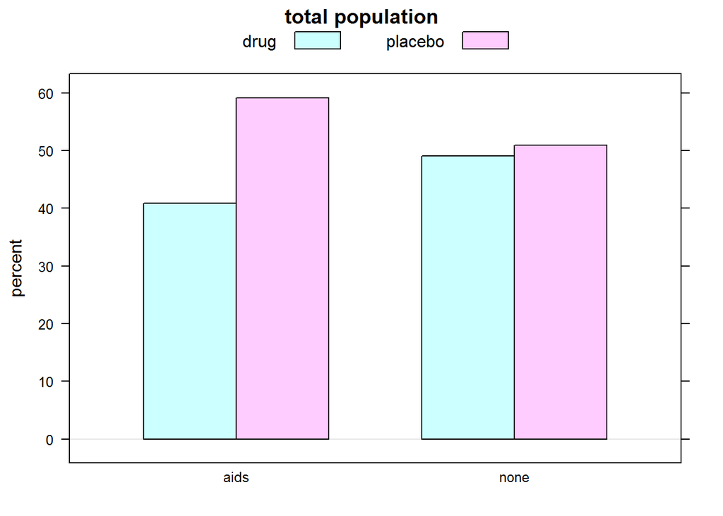

```r
barchartGC(~infected+treatment, data=avast, type="percent", main="total population")
```

There are less people that are taking the drug are reporting being affectecd by aids compared to the same group who are taking the placebo.

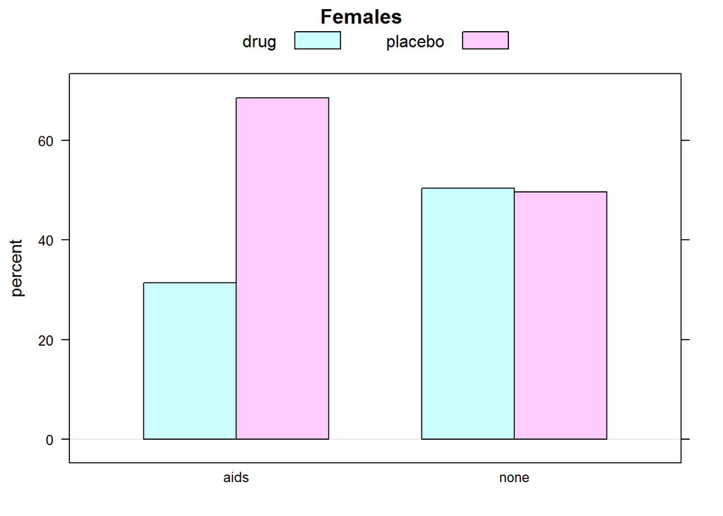

```r
barchartGC(~infected+treatment, data=filter(avast, sex=="gal"), type="percent", main="Females")
```

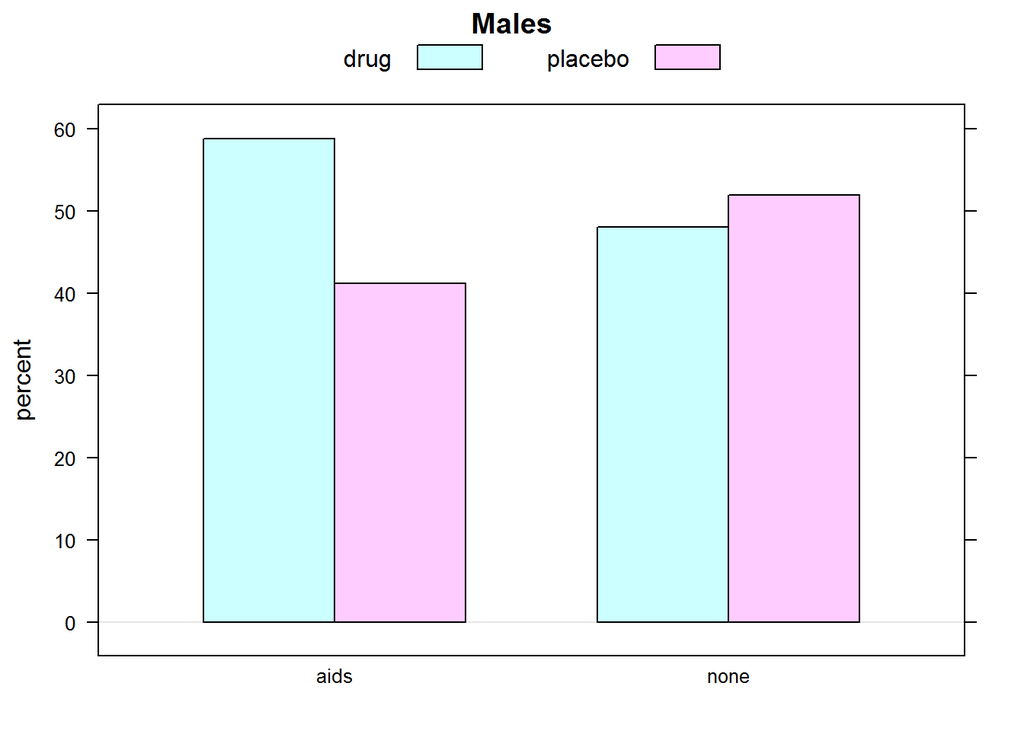

```r
barchartGC(~infected+treatment, data=filter(avast, sex=="guy"), type="percent", main="Males")
```

In this graph the group of males that have contracted aids the males taking the drug are at 59% and the males that are taking the placebo are 40%. Therefore there is an increased risk of contracting aids for the males. The none group of males the placebo group is at 50% and the drug group is at 47%.

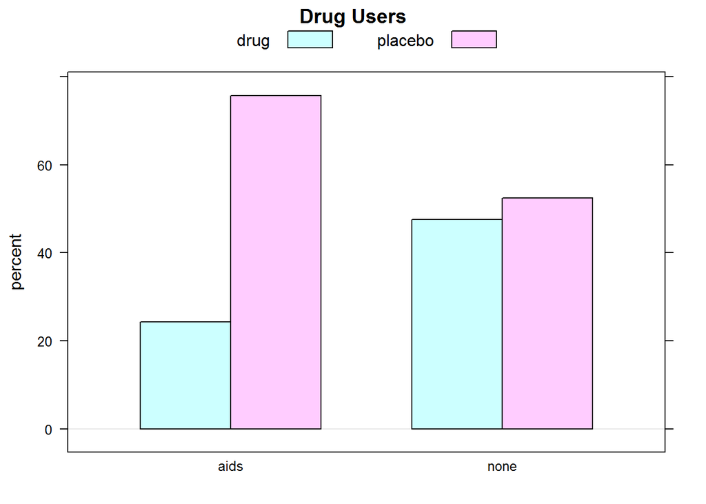

```r
barchartGC(~infected+treatment, data=filter(avast, DrugUser=="yes"), type="percent", main="Drug Users")
```

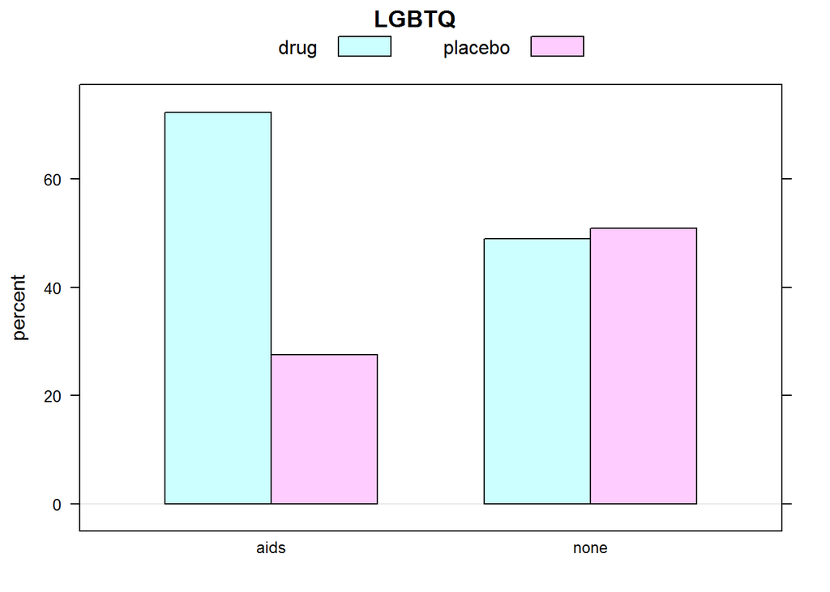

```r
barchartGC(~infected+treatment, data=filter(avast, LGBTQ=="gay"), type="percent", main="LGBTQ")
```

### Numerical Descriptive Results

```r
tab1 = xtabs(~infected+treatment, data=avast)
rowPerc(tab1)
```

```
##         treatment
## infected   drug placebo  Total
##     aids  40.87   59.13 100.00
##     none  49.10   50.90 100.00
```

```r
tab2= xtabs(~infected+treatment, data=filter(avast, sex=="gal"))
rowPerc(tab2)
```

```
##         treatment
## infected   drug placebo  Total
##     aids  31.42   68.58 100.00
##     none  50.38   49.62 100.00
```

In this chart it shows that the people that have contracted aids the females that have taken the drug are at 31.42% and the female group that are taking the placebo are at 68.58%. It is shown that the population of females taking the placebop is higher than the ones taking the drug.

```r
tab3= xtabs(~infected+treatment, data=filter(avast, sex=="guy"))
rowPerc(tab3)
```

```
##         treatment
## infected   drug placebo  Total
##     aids  58.82   41.18 100.00
##     none  48.06   51.94 100.00
```

In this chart it shows that the drug group of men that have contracted aids is at 58.82% copmpared to the male group that is taking placebos is at 41.18%. This means that the drug is not working for the males and males are at more risk of contracting aids.

```r
tab4 = xtabs(~infected+treatment, data=filter(avast, DrugUser=="yes"))
rowPerc(tab4)
```

```
##         treatment
## infected   drug placebo  Total
##     aids  24.29   75.71 100.00
##     none  47.59   52.41 100.00
```

In this chart it shows that the drug users that have contracted aids and that are taking drugs are at 24.29% and the group that are taking placebos are at 75.71%. This means that the drug is workling and that this group is at less of a risk from contracting aids. The group that is none has a percentage of people that have been taking the drugs that are at 47.59% and the people that are taking the placebo that are at 52.41%.

```r
tab5 = xtabs(~infected+treatment, data=filter(avast, LGBTQ=="gay"))
rowPerc(tab5)
```

```
##         treatment
## infected   drug placebo  Total
##     aids  72.38   27.62 100.00
##     none  49.05   50.95 100.00
```

In this chart there is a percentage of 72.38% from the LGBTQ group that has contracted aids and is taking the drug compared to the group that is taking the placebo 27.62%. Since the drug percentage is higher than the placebo this means the LGBTQ group is more at risk of contracting aids. In the none group there is a 1.9% of a difference.

## Inferential Results

```r
chisqtestGC(tab1)
```

```
## Pearson's Chi-squared test with Yates' continuity correction
##
## Observed Counts:
##         treatment
## infected  drug placebo
##     aids   423     612
##     none 10168   10540
##
## Counts Expected by Null:
##         treatment
## infected     drug  placebo
##     aids   504.15   530.85
##     none 10086.85 10621.15
##
## Contributions to the chi-square statistic:
##         treatment
## infected  drug placebo
##     aids 13.06   12.40
##     none  0.65    0.62
##
##
## Chi-Square Statistic = 26.4104
## Degrees of Freedom of the table = 1
## P-Value = 0
```

Our Pvalue shows as 0 therefore we reject the null hypotheis, $H_0$:“There is no effect of the drug on if our population contracted aids or not.” Thus we can conclude that there is an effect on the drug on whether it effects the total population contracts aids or not.

```r
chisqtestGC(tab2)
```

```
## Pearson's Chi-squared test with Yates' continuity correction
##
## Observed Counts:
##         treatment
## infected drug placebo
##     aids  213     465
##     none 4684    4613
##
## Counts Expected by Null:
##         treatment
## infected    drug placebo
##     aids  332.85  345.15
##     none 4564.15 4732.85
##
## Contributions to the chi-square statistic:
##         treatment
## infected  drug placebo
##     aids 43.15   41.62
##     none  3.15    3.03
##
##
## Chi-Square Statistic = 90.1943
## Degrees of Freedom of the table = 1
## P-Value = 0
```

Our Pvalue is 0 therefore we reject the null hypothesis, $H_0$:“There is no effect of the drug on if our female population contracted aids or not.” Thus we can conclude that there is an effect on the drug on whether it effects the female group contracts aids or not.

```r
chisqtestGC(tab3)
```

```
## Pearson's Chi-squared test with Yates' continuity correction
##
## Observed Counts:
##         treatment
## infected drug placebo
##     aids  210     147
##     none 5484    5927
##
## Counts Expected by Null:
##         treatment
## infected    drug placebo
##     aids  172.74  184.26
##     none 5521.26 5889.74
##
## Contributions to the chi-square statistic:
##         treatment
## infected drug placebo
##     aids 8.04    7.54
##     none 0.25    0.24
##
##
## Chi-Square Statistic = 15.6339
## Degrees of Freedom of the table = 1
## P-Value = 1e-04
```

```r
chisqtestGC(tab4)
```

```
## Pearson's Chi-squared test with Yates' continuity correction
##
## Observed Counts:
##         treatment
## infected drug placebo
##     aids   34     106
##     none 1143    1259
##
## Counts Expected by Null:
##         treatment
## infected    drug placebo
##     aids   64.82   75.18
##     none 1112.18 1289.82
##
## Contributions to the chi-square statistic:
##         treatment
## infected  drug placebo
##     aids 14.66   12.64
##     none  0.85    0.74
##
##
## Chi-Square Statistic = 27.955
## Degrees of Freedom of the table = 1
## P-Value = 0
```

This chart the pvalue is 0 therefore we are rejecting the null hypothesis, $H_0$:“There is no effect of the drug on if our drug users population contracted aids or not.” Thus this makes the drug users at less of a risk to contract aids and the drugs are working.

```r
chisqtestGC(tab4)
```

[output not shown]

[output not shown]

# Discussion and Conclusion

The drug worked for the female peopulation, total population and drug user population. They are at less of a risk to contract aids. Howerver the drug did not work on the male and LGBTQ populations. Therefore they are more at risk of contracting aids.